# Monarch_Treatment-Diet

Kaley Hallmark

Started 2/22/2022

## Main Questions: Treatment and Diet Effects on Physiology and Flight Metabolic Rate

### Treatment

- Did we successfully produce phenotypically distinct individuals with our rearing treatments?
  - *Wing morphology*

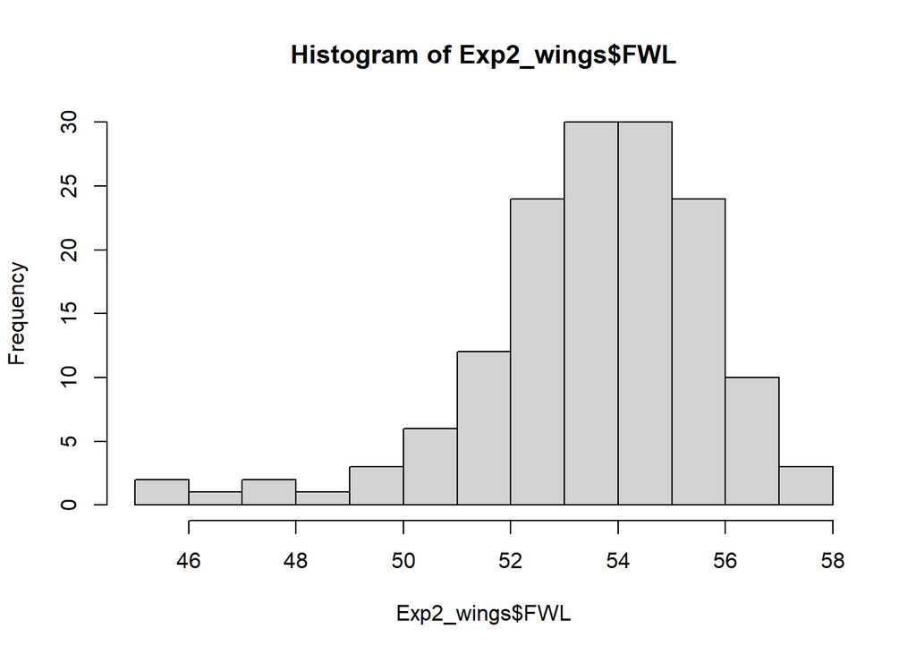

```r
Exp2_wings <- read.csv("https://raw.githubusercontent.com/Kaley-H/Monarch_Treatment-Diet/main/Wing_morphology.csv?token=GHSAT0AAAAAABRXCDR52GK5OWD3IQBZ2LS2YQ7CBPQ")

hist(Exp2_wings$FWL)
```

```r
shapiro.test(Exp2_wings$FWL)
```

```
##
##  Shapiro-Wilk normality test
##
## data:  Exp2_wings$FWL
## W = 0.92607, p-value = 6.2e-07
```

```r
skewness(Exp2_wings$FWL, na.rm = TRUE) #not sure how much this matters that it's not normal
```

```
## [1] -1.195626
```

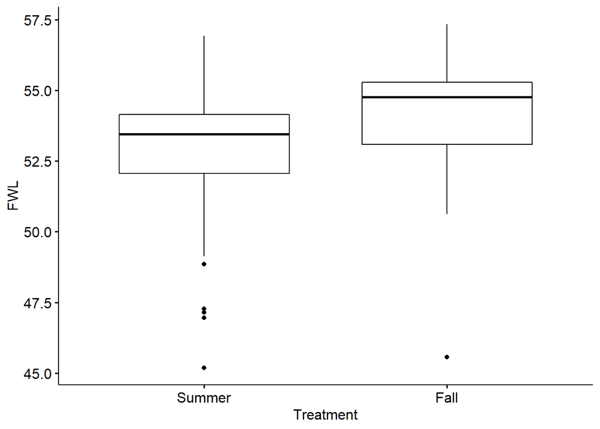

```r
ggboxplot(Exp2_wings, x = "Treatment", y = "FWL")
```

```r
#Models
#Full linear model
#Forewing length
Anova(lm(FWL~Treatment*Plant*Sex, data = Exp2_wings), type = 3) #no significant interactions
```

```
## Anova Table (Type III tests)
##
## Response: FWL
##                     Sum Sq  Df   F value  Pr(>F)
## (Intercept)          35150   1 8552.8167 < 2e-16 ***
## Treatment               20   1    4.8173 0.02982 *
## Plant                    1   1    0.1702 0.68059
## Sex                     14   1    3.2995 0.07144 .
## Treatment:Plant          2   1    0.3782 0.53955
## Treatment:Sex            1   1    0.1440 0.70494
## Plant:Sex                7   1    1.7283 0.19078
## Treatment:Plant:Sex      1   1    0.1270 0.72210
## Residuals              575 140
## ---
## Signif. codes:  0 '***' 0.001 '**' 0.01 '*' 0.05 '.' 0.1 ' ' 1
```

```r
Anova(lm(FWL~Treatment+Plant+Sex, data = Exp2_wings), type = 2)
```

```
## Anova Table (Type II tests)
##
## Response: FWL
##           Sum Sq  Df F value   Pr(>F)
## Treatment  51.52   1 12.3354 0.000594 ***
## Plant      20.44   1  4.8948 0.028512 *
## Sex        18.18   1  4.3529 0.038709 *
## Residuals 601.37 144
## ---
## Signif. codes:  0 '***' 0.001 '**' 0.01 '*' 0.05 '.' 0.1 ' ' 1
```

```r
#Forewing width
Anova(lm(FWW~Treatment*Plant*Sex, data = Exp2_wings), type = 3) #no significant interactions
```

```
## Anova Table (Type III tests)
##
## Response: FWW
##                     Sum Sq  Df   F value  Pr(>F)
## (Intercept)         9343.2   1 7078.9486 < 2e-16 ***
## Treatment              4.6   1    3.4580 0.06505 .
## Plant                  1.5   1    1.1543 0.28450
## Sex                    0.6   1    0.4392 0.50859
## Treatment:Plant        0.1   1    0.1026 0.74920
## Treatment:Sex          1.1   1    0.8415 0.36054
## Plant:Sex              1.9   1    1.4105 0.23699
## Treatment:Plant:Sex    0.0   1    0.0156 0.90081
## Residuals            184.8 140
## ---
## Signif. codes:  0 '***' 0.001 '**' 0.01 '*' 0.05 '.' 0.1 ' ' 1
```

```r
Anova(lm(FWW~Treatment+Plant+Sex, data = Exp2_wings), type = 2)
```

```
## Anova Table (Type II tests)
##
## Response: FWW
##            Sum Sq  Df F value    Pr(>F)
## Treatment   4.953   1  3.7013 0.0563417 .
## Plant      17.205   1 12.8570 0.0004596 ***
## Sex         1.709   1  1.2772 0.2603054
## Residuals 192.703 144
## ---
## Signif. codes:  0 '***' 0.001 '**' 0.01 '*' 0.05 '.' 0.1 ' ' 1
```

```r
#Hindwing length
Anova(lm(HWL~Treatment*Plant*Sex, data = Exp2_wings), type = 3) #no significant interactions
```

```
## Anova Table (Type III tests)
##
## Response: HWL
##                      Sum Sq  Df   F value Pr(>F)
## (Intercept)         15565.7   1 7739.9686 <2e-16 ***
## Treatment               5.3   1    2.6455 0.1061
## Plant                   0.1   1    0.0295 0.8638
## Sex                     1.7   1    0.8619 0.3548
## Treatment:Plant         0.5   1    0.2474 0.6197
## Treatment:Sex           0.4   1    0.1780 0.6737
## Plant:Sex               4.3   1    2.1559 0.1443
## Treatment:Plant:Sex     0.0   1    0.0233 0.8788
## Residuals             281.6 140
## ---
## Signif. codes:  0 '***' 0.001 '**' 0.01 '*' 0.05 '.' 0.1 ' ' 1
```

```r
Anova(lm(HWL~Treatment+Plant+Sex, data = Exp2_wings), type = 2)
```

```
## Anova Table (Type II tests)
##
## Response: HWL
##            Sum Sq  Df F value   Pr(>F)
## Treatment  30.812   1 15.0601 0.000158 ***
## Plant      15.461   1  7.5569 0.006744 **
## Sex         0.024   1  0.0115 0.914567
## Residuals 294.613 144
## ---
## Signif. codes:  0 '***' 0.001 '**' 0.01 '*' 0.05 '.' 0.1 ' ' 1
```

```r
#Hindwing width
Anova(lm(HWW~Treatment*Plant*Sex, data = Exp2_wings), type = 3) #no significant interactions
```

```
## Anova Table (Type III tests)
##
## Response: HWW
##                      Sum Sq  Df   F value  Pr(>F)
## (Intercept)         13113.6   1 6524.4616 < 2e-16 ***
## Treatment               7.2   1    3.5975 0.05993 .
## Plant                   2.8   1    1.4105 0.23698
## Sex                     1.3   1    0.6665 0.41567
## Treatment:Plant         0.0   1    0.0016 0.96834
## Treatment:Sex           0.0   1    0.0001 0.99415
## Plant:Sex               1.3   1    0.6709 0.41412
## Treatment:Plant:Sex     0.5   1    0.2553 0.61414
## Residuals             281.4 140
## ---
## Signif. codes:  0 '***' 0.001 '**' 0.01 '*' 0.05 '.' 0.1 ' ' 1
```

```r
Anova(lm(HWW~Treatment+Plant+Sex, data = Exp2_wings), type = 2)
```

```
## Anova Table (Type II tests)
##
## Response: HWW
##            Sum Sq  Df F value    Pr(>F)
## Treatment  26.150   1  13.244 0.0003803 ***
## Plant      21.668   1  10.974 0.0011682 **
## Sex         2.346   1   1.188 0.2775545
## Residuals 284.320 144
## ---
## Signif. codes:  0 '***' 0.001 '**' 0.01 '*' 0.05 '.' 0.1 ' ' 1
```

```r
#Individual effects
#FWL ~ Treatment
summary(aov(FWL~Treatment, Exp2_wings))
```

```
##              Df Sum Sq Mean Sq F value   Pr(>F)
## Treatment     1   58.5   58.54   13.32 0.000365 ***
## Residuals   146  641.8    4.40
## ---
## Signif. codes:  0 '***' 0.001 '**' 0.01 '*' 0.05 '.' 0.1 ' ' 1
```

```r
an1 <- Exp2_wings %>% anova_test(FWL ~ Treatment) %>% add_significance("p")
```

```
## Coefficient covariances computed by hccm()
```

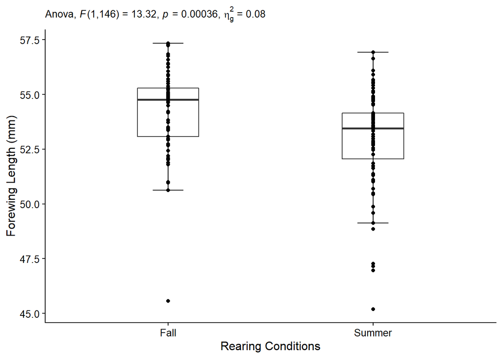

```r
ggplot(Exp2_wings, aes(x = Treatment, y = FWL)) +
  geom_boxplot(width = 0.3) + stat_boxplot(geom = "errorbar", width = 0.15) +
  labs(x = "Rearing Conditions", y = "Forewing Length (mm)", subtitle = get_test_label(an1, detailed = TRUE)) +
  theme_cowplot(12) + geom_jitter(width = 0)
```

```r
rm(an1)

#HWL ~ Treatment
summary(aov(HWL~Treatment, Exp2_wings))
```

```
##              Df Sum Sq Mean Sq F value  Pr(>F)
## Treatment     1  30.72  30.716   14.46 0.00021 ***
## Residuals   146 310.18   2.125
## ---
## Signif. codes:  0 '***' 0.001 '**' 0.01 '*' 0.05 '.' 0.1 ' ' 1
```

```r
an2 <- Exp2_wings %>% anova_test(HWL ~ Treatment) %>% add_significance("p")
```

```
## Coefficient covariances computed by hccm()
```

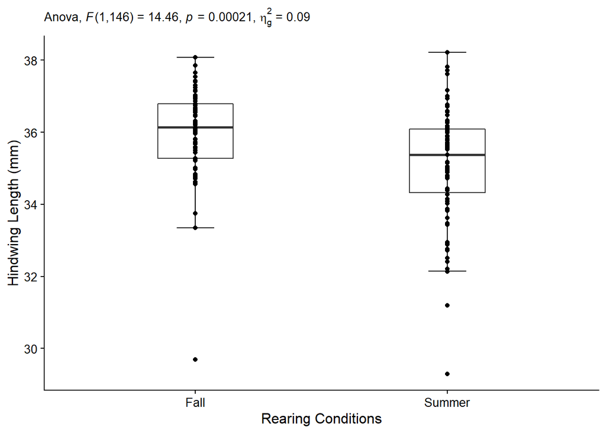

```r
ggplot(Exp2_wings, aes(x = Treatment, y = HWL)) +
  geom_boxplot(width = 0.3) + stat_boxplot(geom = "errorbar", width = 0.15) +
  labs(x = "Rearing Conditions", y = "Hindwing Length (mm)", subtitle = get_test_label(an2, detailed = TRUE)) +
  theme_cowplot(12) + geom_jitter(width = 0)
```

```r
rm(an2)

#FWL ~ Sex
summary(aov(FWL~Sex, data = Exp2_wings))
```

```
##              Df Sum Sq Mean Sq F value Pr(>F)
## Sex           1   28.4  28.378   6.166 0.0142 *
## Residuals   146  672.0   4.602
## ---
## Signif. codes:  0 '***' 0.001 '**' 0.01 '*' 0.05 '.' 0.1 ' ' 1
```

```r
an4 <- Exp2_wings %>% anova_test(FWL ~ Sex) %>% add_significance("p")
```

```
## Coefficient covariances computed by hccm()
```

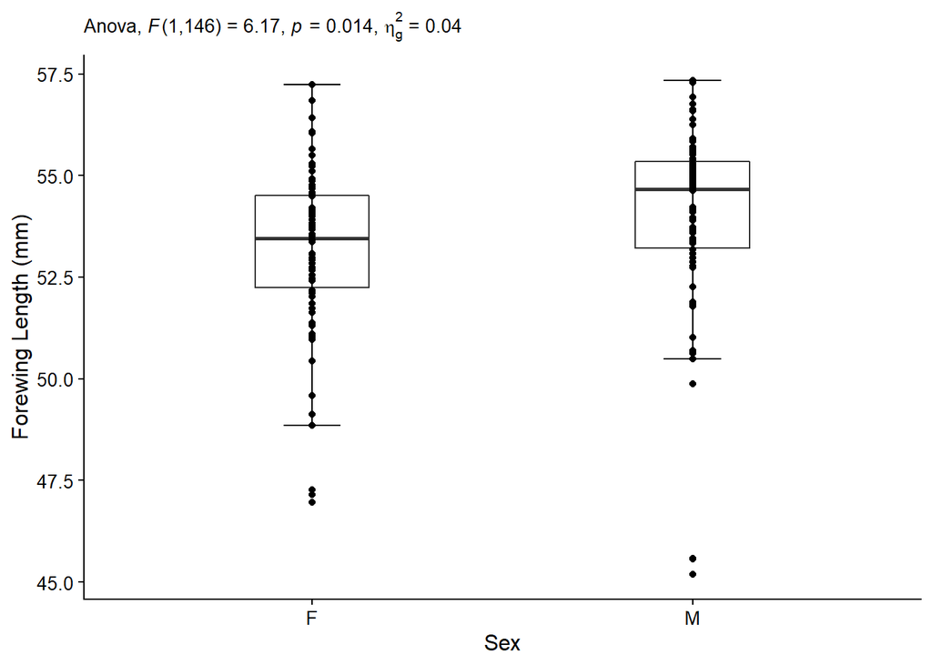

```r
ggplot(Exp2_wings, aes(x = Sex, y = FWL)) +
  geom_boxplot(width = 0.3) + stat_boxplot(geom = "errorbar", width = 0.15) +
  labs(y = "Forewing Length (mm)", subtitle = get_test_label(an4, detailed = TRUE))+   theme_cowplot(12) + geom_jitter(width = 0)
```

```r
rm(an4)

#HWL ~ Sex
summary(aov(HWL~Sex, data = Exp2_wings)) #unequal variances - tried a Welch's Anova as well but didn't change the p-value much
```

```
##              Df Sum Sq Mean Sq F value Pr(>F)
## Sex           1    0.9   0.941   0.404  0.526
## Residuals   146  340.0   2.329
```

```r
an3 <- Exp2_wings %>% anova_test(HWL ~ Sex) %>% add_significance("p")
```

```
## Coefficient covariances computed by hccm()
```

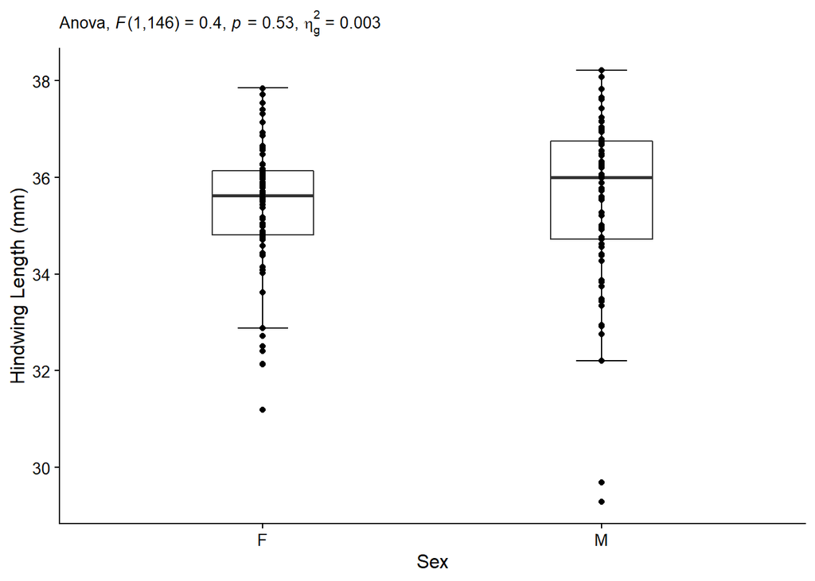

```r
ggplot(Exp2_wings, aes(x = Sex, y = HWL)) +
  geom_boxplot(width = 0.3) + stat_boxplot(geom = "errorbar", width = 0.15) +
  labs(y = "Hindwing Length (mm)", subtitle = get_test_label(an3, detailed = TRUE))+   theme_cowplot(12) + geom_jitter(width = 0)
```

```r
rm(an3)
```

- Did we successfully produce phenotypically distinct individuals with our rearing treatments?
  - *Wing morphology*
  - *Egg counts*
- Is there a difference in metabolic rates (resting and active) between fall- and summer-reared butterflies?

```r
Exp_2_data_08_07_21 <- read.csv("https://raw.githubusercontent.com/Kaley-H/Monarch_Treatment-Diet/main/Respirometry_data.csv?token=GHSAT0AAAAAABRXCDR46RGKBDFMKZ6G6HKAYQ63HMQ")
Exp_2_data_08_07_21$Age <- as.factor(Exp_2_data_08_07_21$Age)
Exp_2_data_08_07_21$Sex <- as.factor(Exp_2_data_08_07_21$Sex)

#Full models
Anova(lm(mlHrCO2_avg~Treatment*pre_flight_weight*Sex, data = Exp_2_data_08_07_21), type = 3)
```

```
## Anova Table (Type III tests)
##
## Response: mlHrCO2_avg
##                                 Sum Sq Df F value   Pr(>F)
## (Intercept)                      86.07  1 10.4492 0.002271 **
## Treatment                        24.63  1  2.9898 0.090497 .
## pre_flight_weight                 1.44  1  0.1752 0.677484
## Sex                              39.89  1  4.8430 0.032817 *
## Treatment:pre_flight_weight      24.38  1  2.9593 0.092109 .
## Treatment:Sex                    37.61  1  4.5658 0.037967 *
## pre_flight_weight:Sex            31.95  1  3.8786 0.054946 .
## Treatment:pre_flight_weight:Sex  27.13  1  3.2932 0.076093 .
## Residuals                       378.92 46
## ---
## Signif. codes:  0 '***' 0.001 '**' 0.01 '*' 0.05 '.' 0.1 ' ' 1
```

```r
Anova(lm(rmr_mlHrCO2~Treatment*pre_flight_weight*Sex, data = Exp_2_data_08_07_21), type = 3)
```

```
## Anova Table (Type III tests)
##
## Response: rmr_mlHrCO2
##                                  Sum Sq Df F value  Pr(>F)
## (Intercept)                     0.00388  1  0.0774 0.78205
## Treatment                       0.00863  1  0.1723 0.68003
## pre_flight_weight               0.21362  1  4.2641 0.04459 *
## Sex                             0.01155  1  0.2305 0.63342
## Treatment:pre_flight_weight     0.00026  1  0.0053 0.94246
## Treatment:Sex                   0.01079  1  0.2153 0.64483
## pre_flight_weight:Sex           0.03241  1  0.6469 0.42537
## Treatment:pre_flight_weight:Sex 0.02767  1  0.5523 0.46116
## Residuals                       2.30445 46
## ---
## Signif. codes:  0 '***' 0.001 '**' 0.01 '*' 0.05 '.' 0.1 ' ' 1
```

```r
Anova(lm(mlHrCO2_peak~Treatment*pre_flight_weight*Sex, data = Exp_2_data_08_07_21), type = 3)
```

```
## Anova Table (Type III tests)
##
## Response: mlHrCO2_peak
##                                 Sum Sq Df F value   Pr(>F)
## (Intercept)                     125.92  1 11.9124 0.001206 **
## Treatment                        45.80  1  4.3327 0.042979 *
## pre_flight_weight                 1.05  1  0.0992 0.754272
## Sex                              30.49  1  2.8842 0.096211 .
## Treatment:pre_flight_weight      51.27  1  4.8498 0.032700 *
## Treatment:Sex                    42.20  1  3.9926 0.051633 .
## pre_flight_weight:Sex            25.65  1  2.4270 0.126119
## Treatment:pre_flight_weight:Sex  31.89  1  3.0173 0.089072 .
## Residuals                       486.24 46
## ---
## Signif. codes:  0 '***' 0.001 '**' 0.01 '*' 0.05 '.' 0.1 ' ' 1
```

```r
Anova(lm(mlHrCO2_peak~Treatment+pre_flight_weight+Sex, data = Exp_2_data_08_07_21), type = 2)
```

```
## Anova Table (Type II tests)
##
## Response: mlHrCO2_peak
##                   Sum Sq Df F value  Pr(>F)
## Treatment          59.46  1  5.1028 0.02828 *
## pre_flight_weight  65.74  1  5.6419 0.02141 *
## Sex                10.56  1  0.9066 0.34560
## Residuals         582.63 50
## ---
## Signif. codes:  0 '***' 0.001 '**' 0.01 '*' 0.05 '.' 0.1 ' ' 1
```

```r
Anova(lm(rmr_mlHrCO2~Treatment+pre_flight_weight+Sex+Plant, data = Exp_2_data_08_07_21), type = 2)
```

```
## Anova Table (Type II tests)
##
## Response: rmr_mlHrCO2
##                    Sum Sq Df F value    Pr(>F)
## Treatment         0.09370  1  2.0299 0.1605728
## pre_flight_weight 0.57499  1 12.4564 0.0009169 ***
## Sex               0.03762  1  0.8150 0.3710516
## Plant             0.19167  1  4.1524 0.0469939 *
## Residuals         2.26185 49
## ---
## Signif. codes:  0 '***' 0.001 '**' 0.01 '*' 0.05 '.' 0.1 ' ' 1
```

```r
Anova(lm(mlHrCO2_avg~Treatment+pre_flight_weight+Sex+Plant, data = Exp_2_data_08_07_21), type = 2)
```

```
## Anova Table (Type II tests)
##
## Response: mlHrCO2_avg
##                   Sum Sq Df F value  Pr(>F)
## Treatment          20.80  1  2.3639 0.13061
## pre_flight_weight  43.44  1  4.9375 0.03093 *
## Sex                 0.93  1  0.1056 0.74655
## Plant              31.56  1  3.5870 0.06414 .
## Residuals         431.08 49
## ---
## Signif. codes:  0 '***' 0.001 '**' 0.01 '*' 0.05 '.' 0.1 ' ' 1
```

```r
Anova(lm(mlHrCO2_peak~Treatment+pre_flight_weight+Sex+Plant, data = Exp_2_data_08_07_21), type = 2)
```

```
## Anova Table (Type II tests)
##
## Response: mlHrCO2_peak
##                   Sum Sq Df F value  Pr(>F)
## Treatment          40.56  1  3.6415 0.06222 .
## pre_flight_weight  64.66  1  5.8053 0.01978 *
## Sex                 7.16  1  0.6430 0.42651
## Plant              36.89  1  3.3120 0.07489 .
## Residuals         545.74 49
## ---
## Signif. codes:  0 '***' 0.001 '**' 0.01 '*' 0.05 '.' 0.1 ' ' 1
```

```r
Anova(lm(rmr_mlHrCO2~Treatment*pre_flight_weight*Sex*Plant, data = Exp_2_data_08_07_21), type = 3)
```

```
## Anova Table (Type III tests)
##
## Response: rmr_mlHrCO2
##                                        Sum Sq Df F value    Pr(>F)
## (Intercept)                           0.03857  1  1.9072 0.1753422
## Treatment                             0.01333  1  0.6593 0.4218671
## pre_flight_weight                     0.02445  1  1.2091 0.2784226
## Sex                                   0.00129  1  0.0636 0.8022653
## Plant                                 0.89762  1 44.3851 7.070e-08 ***
## Treatment:pre_flight_weight           0.01039  1  0.5137 0.4779112
## Treatment:Sex                         0.04138  1  2.0464 0.1607408
## pre_flight_weight:Sex                 0.00360  1  0.1779 0.6755340
## Treatment:Plant                       0.57154  1 28.2615 4.927e-06 ***
## pre_flight_weight:Plant               1.07055  1 52.9358 1.045e-08 ***
## Sex:Plant                             0.27744  1 13.7186 0.0006725 ***
## Treatment:pre_flight_weight:Sex       0.04339  1  2.1454 0.1512233
## Treatment:pre_flight_weight:Plant     0.60224  1 29.7791 3.162e-06 ***
## Treatment:Sex:Plant                   0.04810  1  2.3785 0.1313004
## pre_flight_weight:Sex:Plant           0.26005  1 12.8589 0.0009439 ***
## Treatment:pre_flight_weight:Sex:Plant 0.06268  1  3.0991 0.0863814 .
## Residuals                             0.76849 38
## ---
## Signif. codes:  0 '***' 0.001 '**' 0.01 '*' 0.05 '.' 0.1 ' ' 1
```

```r
summary(aov(rmr_mlHrCO2~Treatment, data = Exp_2_data_08_07_21)) # p > 0.05 - not significant
```

```
##             Df Sum Sq Mean Sq F value Pr(>F)
## Treatment    1 0.0432 0.04318   0.731  0.396
## Residuals   52 3.0702 0.05904
```

```r
an_1 <- Exp_2_data_08_07_21 %>% anova_test(rmr_mlHrCO2~Treatment) %>% add_significance("p")
```

```
## Coefficient covariances computed by hccm()
```

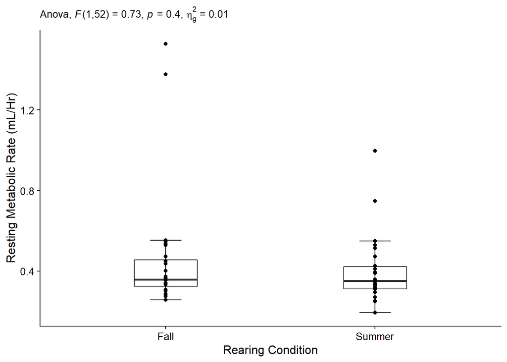

```r
ggplot(Exp_2_data_08_07_21, aes(x = Treatment, y = rmr_mlHrCO2)) +
  geom_boxplot(width = 0.3) + stat_boxplot(geom = "errorbar", width = 0.15) +
  labs(x = "Rearing Condition", y = "Resting Metabolic Rate (mL/Hr)", subtitle = get_test_label(an_1, detailed = TRUE))+   theme_cowplot(12) + geom_jitter(width = 0)
```

```r
rm(an_1)

summary(aov(mlHrCO2_avg~Treatment, data = Exp_2_data_08_07_21)) # p = 0.06 - marginally significant
```

```
##             Df Sum Sq Mean Sq F value Pr(>F)
## Treatment    1   35.0   34.99   3.579 0.0641 .
## Residuals   52  508.4    9.78
## ---
## Signif. codes:  0 '***' 0.001 '**' 0.01 '*' 0.05 '.' 0.1 ' ' 1
```

```r
an_2 <- Exp_2_data_08_07_21 %>% anova_test(mlHrCO2_avg~Treatment) %>% add_significance("p")
```

```
## Coefficient covariances computed by hccm()
```

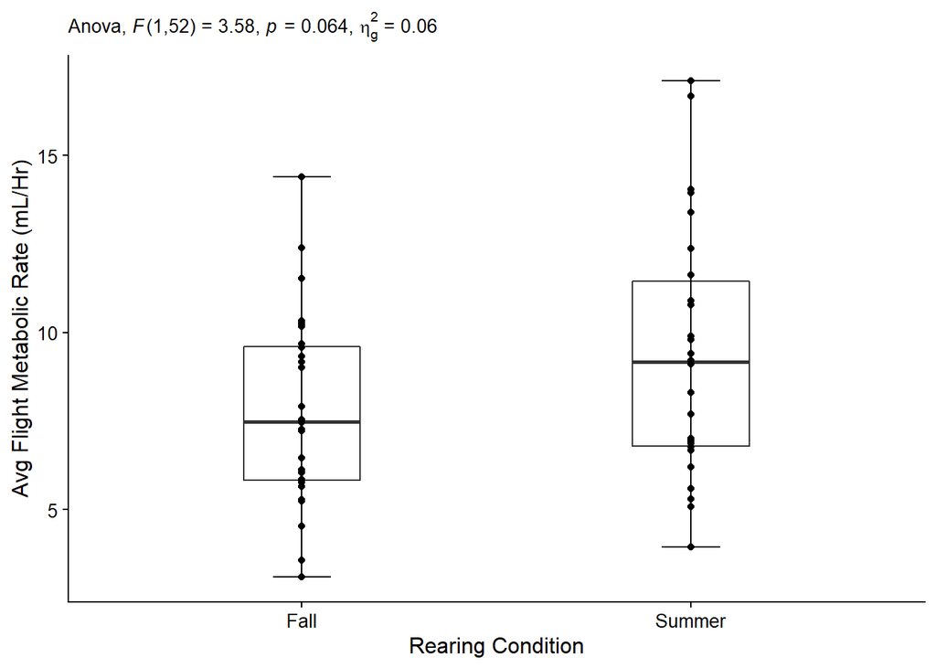

```r
ggplot(Exp_2_data_08_07_21, aes(x = Treatment, y = mlHrCO2_avg)) +
  geom_boxplot(width = 0.3) + stat_boxplot(geom = "errorbar", width = 0.15) +
  labs(x = "Rearing Condition", y = "Avg Flight Metabolic Rate (mL/Hr)", subtitle = get_test_label(an_2, detailed = TRUE))+   theme_cowplot(12) + geom_jitter(width = 0)
```

```r
rm(an_2)
```

- Is there a difference in lipid amounts between fall- and summer-reared butterflies?

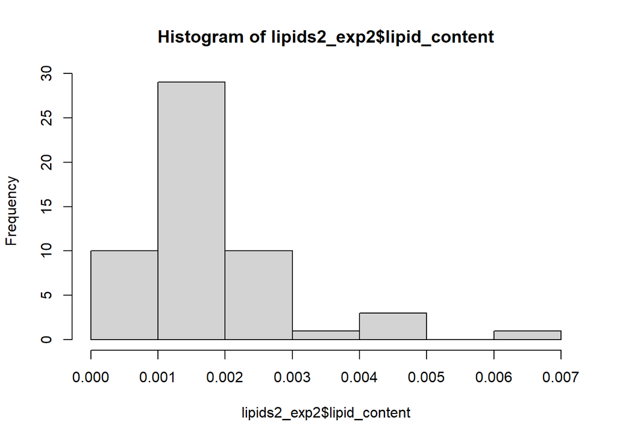

```r
lipids_exp2 <- read.csv("https://raw.githubusercontent.com/Kaley-H/Monarch_Treatment-Diet/main/lipid_content.csv?token=GHSAT0AAAAAABR4K7ME6SS62SK5Y74IK3XMYRAKWPA")
lipids_exp2 <- lipids_exp2 %>% select(-Notes) #remove notes column
lipids_exp2[lipids_exp2 == "" | lipids_exp2 == " "] <- NA #replace cells that are blank or have a space with "NA"
lipids2_exp2 <- na.omit(lipids_exp2)
hist(lipids2_exp2$lipid_content) #data skewed
```

```r
shapiro.test(lipids2_exp2$lipid_content) #normality assumption violated
```

```
##
##  Shapiro-Wilk normality test
##
## data:  lipids2_exp2$lipid_content
## W = 0.78249, p-value = 1.596e-07
```

```r
cor.test(~pre_weight + Age, data = lipids2_exp2, conf.level = 0.95)
```

```
##
##  Pearson's product-moment correlation
##
## data:  pre_weight and Age
## t = -3.164, df = 52, p-value = 0.002599
## alternative hypothesis: true correlation is not equal to 0
## 95 percent confidence interval:
##  -0.6045196 -0.1501945
## sample estimates:
##        cor
## -0.4017964
```

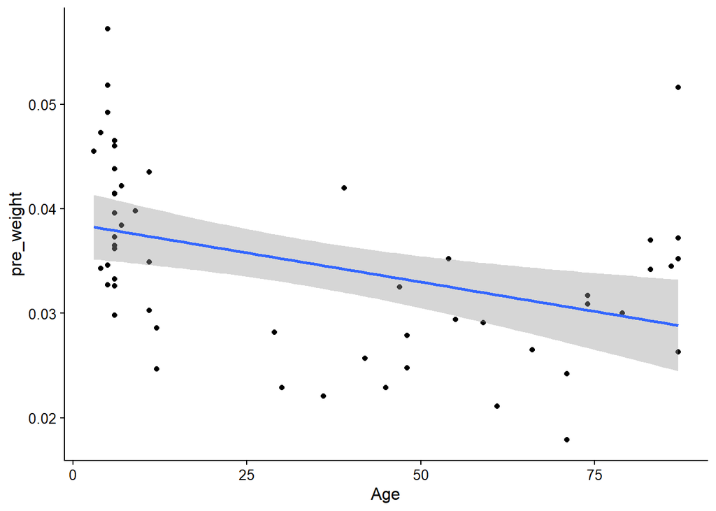

```r
ggplot(lipids2_exp2, aes(x = Age, y = pre_weight)) + geom_point() + geom_smooth(method = lm) + theme_cowplot(12)
```

```r
#data not normally distributed -- don't think this can be analyzed with a linear model

#Full models
#Anova(lm(lipid_content~Treatment*Plant*Sex*Age, data = lipids2_exp2), type = 3) --- gives 'aliased coefficients' error
Anova(lm(lipid_content~Treatment*Plant*Age, data = lipids2_exp2), type = 3) #no interaction effects
```

```
## Anova Table (Type III tests)
##
## Response: lipid_content
##                         Sum Sq Df F value Pr(>F)
## (Intercept)         8.5000e-07  1  0.7470 0.3919
## Treatment           3.7000e-08  1  0.0324 0.8578
## Plant               0.0000e+00  1  0.0001 0.9943
## Age                 5.4000e-08  1  0.0478 0.8280
## Treatment:Plant     6.0000e-09  1  0.0053 0.9422
## Treatment:Age       0.0000e+00  1  0.0001 0.9929
## Plant:Age           1.4100e-07  1  0.1242 0.7261
## Treatment:Plant:Age 1.0000e-09  1  0.0010 0.9753
## Residuals           5.2346e-05 46
```

```r
Anova(lm(lipid_content~Treatment+Plant+Age, data = lipids2_exp2), type = 2) #no significant main effects
```

```
## Anova Table (Type II tests)
##
## Response: lipid_content
##               Sum Sq Df F value Pr(>F)
## Treatment 1.1500e-07  1  0.1076 0.7442
## Plant     2.3380e-06  1  2.1810 0.1460
## Age       1.3100e-07  1  0.1226 0.7277
## Residuals 5.3598e-05 50
```

```r
#compare lipids by treatment
bartlett.test(lipid_content~Treatment, data = lipids2_exp2)
```

```
##
##  Bartlett test of homogeneity of variances
##
## data:  lipid_content by Treatment
## Bartlett's K-squared = 1.8107, df = 1, p-value = 0.1784
```

```r
summary(aov(lipid_content~Treatment, data = lipids2_exp2))
```

```
##             Df    Sum Sq   Mean Sq F value Pr(>F)
## Treatment    1 5.010e-06 5.005e-06    4.58 0.0371 *
## Residuals   52 5.683e-05 1.093e-06
## ---
## Signif. codes:  0 '***' 0.001 '**' 0.01 '*' 0.05 '.' 0.1 ' ' 1
```

```r
an_3 <- lipids2_exp2 %>% anova_test(lipid_content~Treatment) %>% add_significance("p")
```

```
## Coefficient covariances computed by hccm()
```

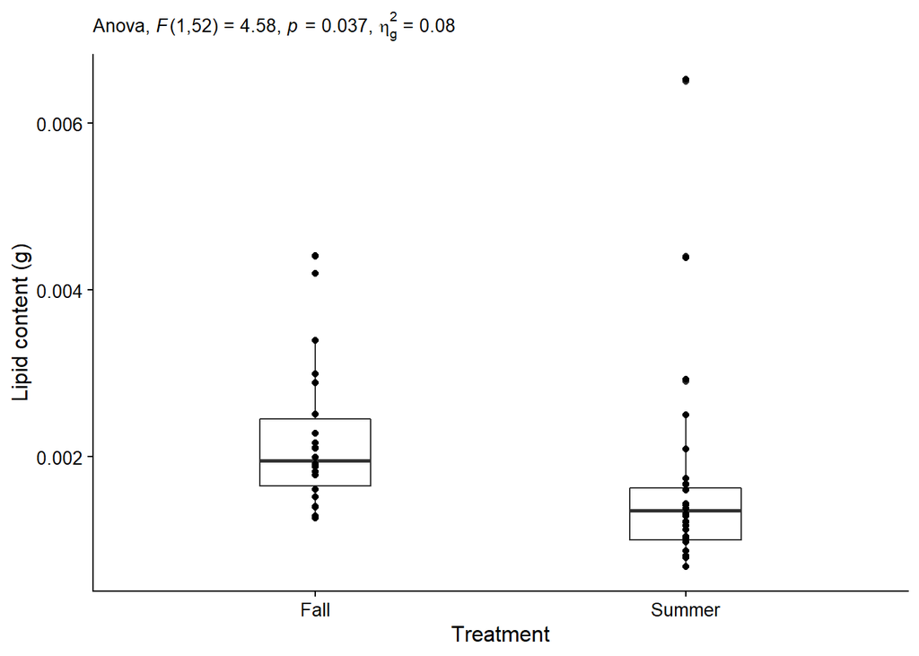

```r
ggplot(lipids2_exp2, aes(x = Treatment, y = lipid_content)) + labs(x = "Treatment", y = "Lipid content (g)", subtitle = get_test_label(an_3, detailed = TRUE)) + geom_boxplot(width = 0.3) + geom_jitter(width = 0) + theme_cowplot(12)
```

```r
rm(an_3)
```

### Diet

- Is butterfly mass and/or wing lengths affected by different larval diets?

```r
#FWL ~ Plant
summary(aov(FWL~Plant, data = Exp2_wings))
```

```
##              Df Sum Sq Mean Sq F value Pr(>F)
## Plant         1   21.0  21.043   4.523 0.0351 *
## Residuals   146  679.3   4.653
## ---
## Signif. codes:  0 '***' 0.001 '**' 0.01 '*' 0.05 '.' 0.1 ' ' 1
```

```r
an5 <- Exp2_wings %>% anova_test(FWL ~ Plant) %>% add_significance("p")
```

```
## Coefficient covariances computed by hccm()
```

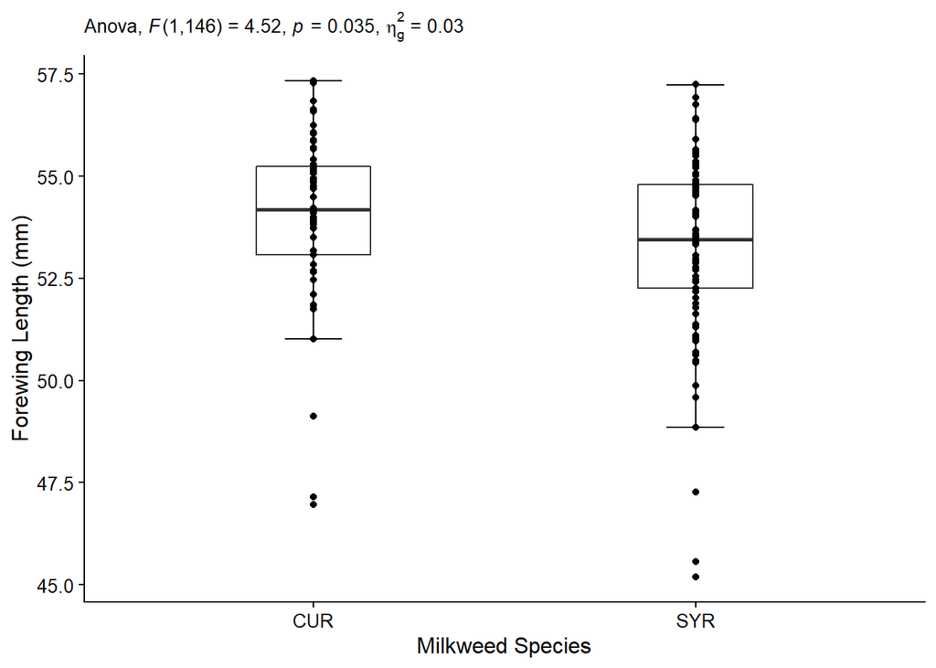

```r
ggplot(Exp2_wings, aes(x = Plant, y = FWL)) +
  geom_boxplot(width = 0.3) + stat_boxplot(geom = "errorbar", width = 0.15) +
  labs(x = "Milkweed Species", y = "Forewing Length (mm)", subtitle = get_test_label(an5, detailed = TRUE))+   theme_cowplot(12) + geom_jitter(width = 0)
```

```r
rm(an5)

#HWL ~ Plant
summary(aov(HWL~Plant, data = Exp2_wings))
```

```
##              Df Sum Sq Mean Sq F value Pr(>F)
## Plant         1   14.8  14.820   6.636  0.011 *
## Residuals   146  326.1   2.233
## ---
## Signif. codes:  0 '***' 0.001 '**' 0.01 '*' 0.05 '.' 0.1 ' ' 1
```

```r
an6 <- Exp2_wings %>% anova_test(HWL ~ Plant) %>% add_significance("p")
```

```
## Coefficient covariances computed by hccm()
```

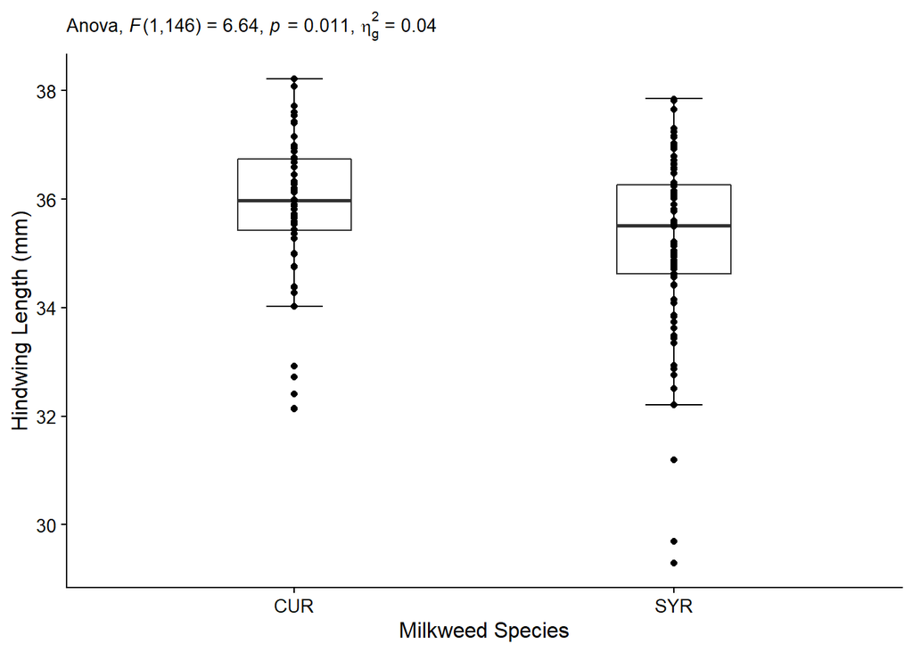

```r
ggplot(Exp2_wings, aes(x = Plant, y = HWL)) +
  geom_boxplot(width = 0.3) + stat_boxplot(geom = "errorbar", width = 0.15) +
  labs(x = "Milkweed Species", y = "Hindwing Length (mm)", subtitle = get_test_label(an6, detailed = TRUE))+   theme_cowplot(12) + geom_jitter(width = 0)
```

```r
rm(an6)
```

- Is there a difference in metabolic rates (resting and active) between diets?

## Other Data Exploration

- Sex or age effects on butterfly mass?
  - *No effect on butterfly mass*

```r
Anova(lm(pre_flight_weight~Age*Sex, data = Exp_2_data_08_07_21), type = 3)
```

```
## Anova Table (Type III tests)
##
## Response: pre_flight_weight
##             Sum Sq Df  F value Pr(>F)
## (Intercept) 4.3106  1 403.8900 <2e-16 ***
## Age         0.0101  2   0.4735 0.6257
## Sex         0.0053  1   0.4938 0.4856
## Age:Sex     0.0056  2   0.2626 0.7701
## Residuals   0.5123 48
## ---
## Signif. codes:  0 '***' 0.001 '**' 0.01 '*' 0.05 '.' 0.1 ' ' 1
```

```r
Anova(lm(pre_flight_weight~Age+Sex, data = Exp_2_data_08_07_21), type = 2)
```

```
## Anova Table (Type II tests)
##
## Response: pre_flight_weight
##            Sum Sq Df F value Pr(>F)
## Age       0.00578  2  0.2789 0.7578
## Sex       0.00153  1  0.1480 0.7021
## Residuals 0.51790 50
```

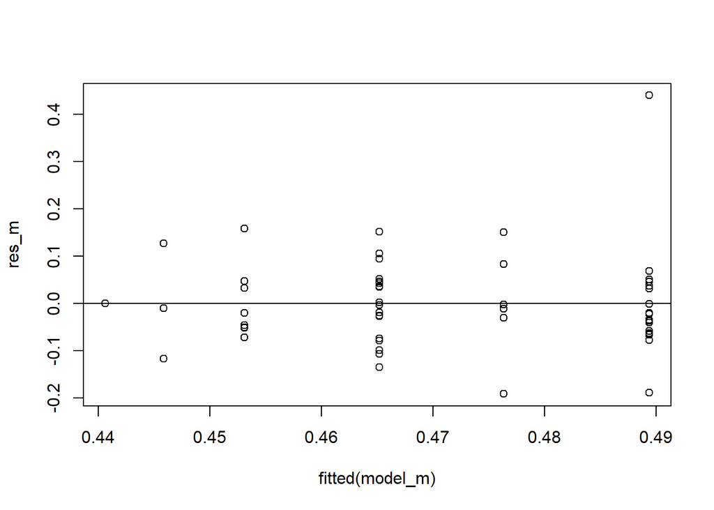

```r
#examine residuals
model_m = aov(pre_flight_weight~Age*Sex, data = Exp_2_data_08_07_21)
res_m = resid(model_m)
plot(fitted(model_m), res_m) #normally distributed
abline(0,0)
```

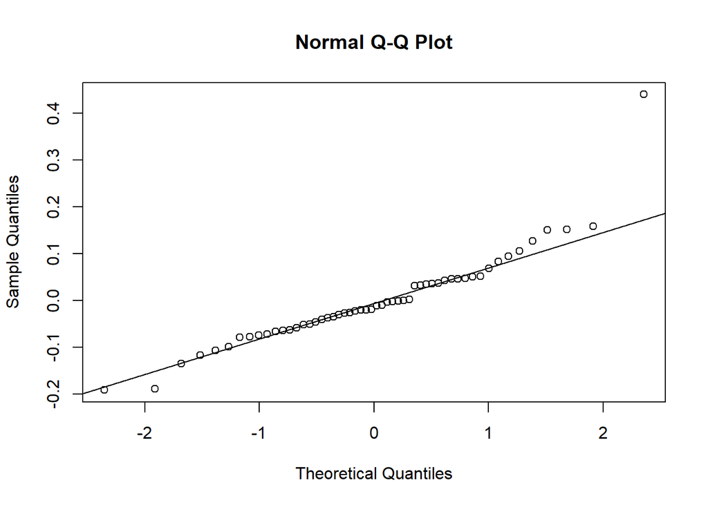

```r
qqnorm(res_m)
qqline(res_m)
```

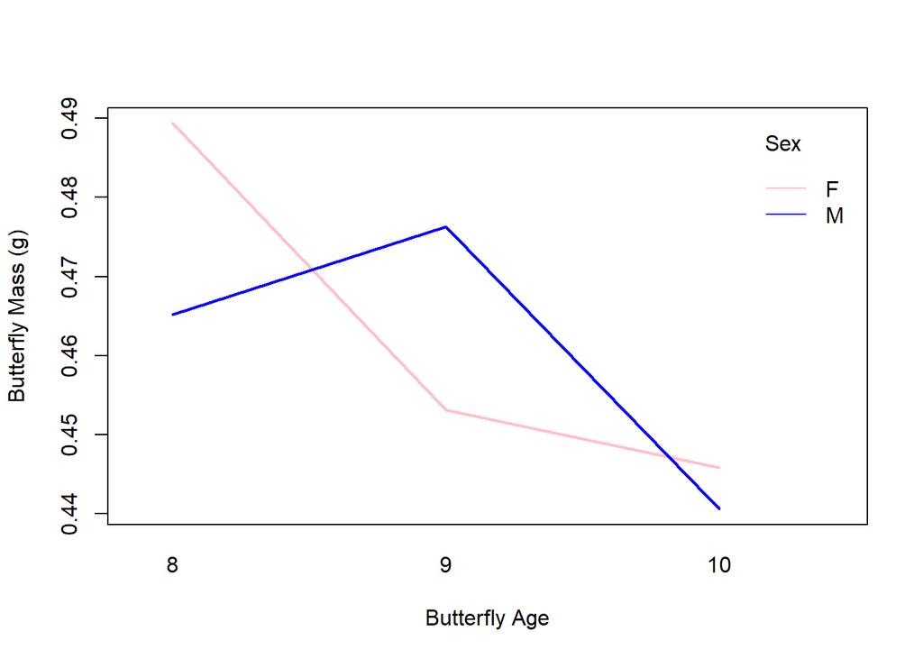

```r
remove(model_m)
remove(res_m)

#interaction plot (should see no interaction)
interaction.plot(x.factor = Exp_2_data_08_07_21$Age, #x-axis variable
                 trace.factor = Exp_2_data_08_07_21$Sex, #variable for lines
                 response = Exp_2_data_08_07_21$pre_flight_weight, #y-axis variable
                 fun = mean, #metric to plot
                 ylab = "Butterfly Mass (g)",
                 xlab = "Butterfly Age",
                 col = c("pink", "blue"),
                 lty = 1, #line type
                 lwd = 2, #line width
                 trace.label = "Sex")
```

```r
#Add in plant effect?
#Anova(lm(pre_flight_weight~Age*Sex*Plant, data = Exp_2_data_08_07_21), type = 3)
#giving aliased coefficients error
Anova(lm(pre_flight_weight~Age+Sex+Plant, data = Exp_2_data_08_07_21), type = 2)
```

```
## Anova Table (Type II tests)
##
## Response: pre_flight_weight
##            Sum Sq Df F value Pr(>F)
## Age       0.00594  2  0.2813 0.7560
## Sex       0.00165  1  0.1565 0.6942
## Plant     0.00028  1  0.0267 0.8708
## Residuals 0.51762 49
```

*Appears to be an interaction in the graph, but not in the stats tests. Probably due to the limited number of data points for days 9 and 10 compared to day 8.*

- Sex or age effects on metabolic rates?
  - *No effect on average flight metabolic rate*
  - *No effect on normalized average flight metabolic rate*
  - *No effect on peak flight metabolic rate*
  - *No effect on resting metabolic rate*
  - *Mildly significant effect on normalized resting metabolic rate*

```r
#Interaction models
#Average flight metabolic rate
Anova(lm(mlHrCO2_avg ~ Age * Sex, data = Exp_2_data_08_07_21), type = 3)
```

```
## Anova Table (Type III tests)
##
## Response: mlHrCO2_avg
##              Sum Sq Df  F value    Pr(>F)
## (Intercept) 1290.47  1 114.9012 2.483e-14 ***
## Age            0.53  2   0.0237    0.9765
## Sex            1.14  1   0.1017    0.7512
## Age:Sex        2.41  2   0.1073    0.8985
## Residuals    539.09 48
## ---
## Signif. codes:  0 '***' 0.001 '**' 0.01 '*' 0.05 '.' 0.1 ' ' 1
```

```r
Anova(lm(mlHrCO2_avg ~ Age + Sex, data = Exp_2_data_08_07_21), type = 2)
```

```
## Anova Table (Type II tests)
##
## Response: mlHrCO2_avg
##           Sum Sq Df F value Pr(>F)
## Age         0.43  2  0.0197 0.9805
## Sex         1.24  1  0.1145 0.7365
## Residuals 541.50 50
```

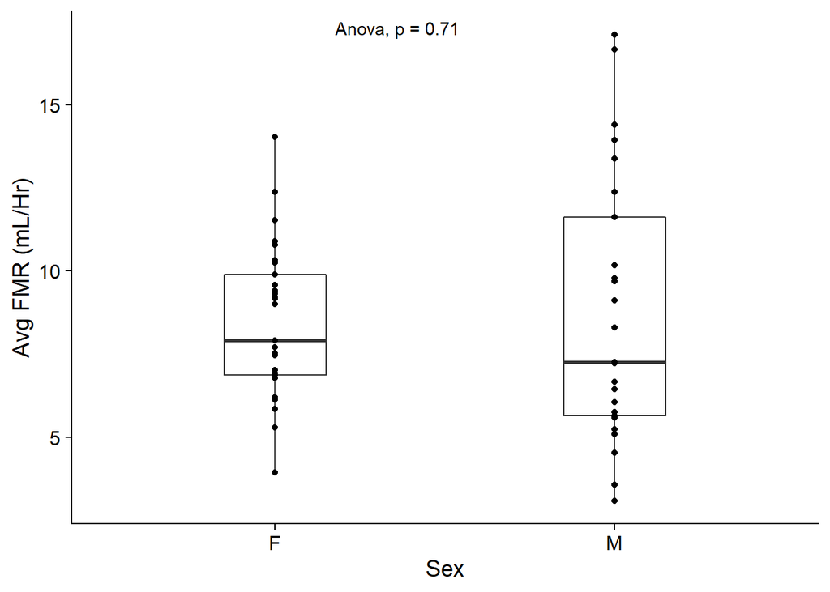

```r
ggplot(Exp_2_data_08_07_21, aes(x = Sex, y = mlHrCO2_avg)) + labs(y = "Avg FMR (mL/Hr)") + geom_boxplot(width = 0.3) + geom_jitter(width = 0) + theme_cowplot() + stat_compare_means(method = "anova", label.x = 1.25)
```

```r
#Normalized average flight metabolic rate
Anova(lm(norm_CO2_avg ~ Age * Sex, data = Exp_2_data_08_07_21), type = 3)
```

```
## Anova Table (Type III tests)
##
## Response: norm_CO2_avg
##             Sum Sq Df  F value    Pr(>F)
## (Intercept) 5699.0  1 134.9631 1.497e-15 ***
## Age            8.5  2   0.1005    0.9045
## Sex            5.9  1   0.1398    0.7102
## Age:Sex       10.4  2   0.1228    0.8847
## Residuals   2026.9 48
## ---
## Signif. codes:  0 '***' 0.001 '**' 0.01 '*' 0.05 '.' 0.1 ' ' 1
```

```r
Anova(lm(norm_CO2_avg ~ Age + Sex, data = Exp_2_data_08_07_21), type = 2)
```

```
## Anova Table (Type II tests)
##
## Response: norm_CO2_avg
##            Sum Sq Df F value Pr(>F)
## Age          4.45  2  0.0547 0.9469
## Sex          4.40  1  0.1080 0.7438
## Residuals 2037.25 50
```

```r
#Peak metabolic rate
Anova(lm(mlHrCO2_peak ~ Age * Sex, data = Exp_2_data_08_07_21), type = 3)
```

```
## Anova Table (Type III tests)
##
## Response: mlHrCO2_peak
##              Sum Sq Df  F value    Pr(>F)
## (Intercept) 2125.07  1 144.4594 4.407e-16 ***
## Age            0.70  2   0.0237    0.9766
## Sex            8.72  1   0.5926    0.4452
## Age:Sex        4.25  2   0.1446    0.8657
## Residuals    706.10 48
## ---
## Signif. codes:  0 '***' 0.001 '**' 0.01 '*' 0.05 '.' 0.1 ' ' 1
```

```r
Anova(lm(mlHrCO2_peak ~ Age + Sex, data = Exp_2_data_08_07_21), type = 2)
```

```
## Anova Table (Type II tests)
##
## Response: mlHrCO2_peak
##           Sum Sq Df F value Pr(>F)
## Age         0.19  2  0.0066 0.9934
## Sex         7.98  1  0.5617 0.4571
## Residuals 710.36 50
```

```r
#Resting metabolic rate
Anova(lm(rmr_mlHrCO2 ~ Age * Sex, data = Exp_2_data_08_07_21), type = 3)
```

```
## Anova Table (Type III tests)
##
## Response: rmr_mlHrCO2
##             Sum Sq Df F value    Pr(>F)
## (Intercept) 3.3878  1 60.8335 4.428e-10 ***
## Age         0.3825  2  3.4338   0.04038 *
## Sex         0.0181  1  0.3256   0.57092
## Age:Sex     0.1915  2  1.7194   0.19002
## Residuals   2.6731 48
## ---
## Signif. codes:  0 '***' 0.001 '**' 0.01 '*' 0.05 '.' 0.1 ' ' 1
```

```r
Anova(lm(rmr_mlHrCO2 ~ Age + Sex, data = Exp_2_data_08_07_21), type = 2)
```

```
## Anova Table (Type II tests)
##
## Response: rmr_mlHrCO2
##            Sum Sq Df F value Pr(>F)
## Age       0.21470  2  1.8738 0.1642
## Sex       0.01707  1  0.2979 0.5876
## Residuals 2.86460 50
```

```r
#Normalized resting metabolic rate
Anova(lm(norm_rmr ~ Age * Sex, data = Exp_2_data_08_07_21), type = 3)
```

```
## Anova Table (Type III tests)
##
## Response: norm_rmr
##              Sum Sq Df F value    Pr(>F)
## (Intercept) 13.9075  1 98.6268 3.175e-13 ***
## Age          1.3845  2  4.9092   0.01149 *
## Sex          0.0173  1  0.1230   0.72732
## Age:Sex      0.6487  2  2.3002   0.11119
## Residuals    6.7685 48
## ---
## Signif. codes:  0 '***' 0.001 '**' 0.01 '*' 0.05 '.' 0.1 ' ' 1
```

```r
Anova(lm(norm_rmr ~ Age + Sex, data = Exp_2_data_08_07_21), type = 2)
```

```
## Anova Table (Type II tests)
##
## Response: norm_rmr
##           Sum Sq Df F value  Pr(>F)
## Age       0.8225  2  2.7721 0.07216 .
## Sex       0.0207  1  0.1396 0.71030
## Residuals 7.4172 50
## ---
## Signif. codes:  0 '***' 0.001 '**' 0.01 '*' 0.05 '.' 0.1 ' ' 1
```

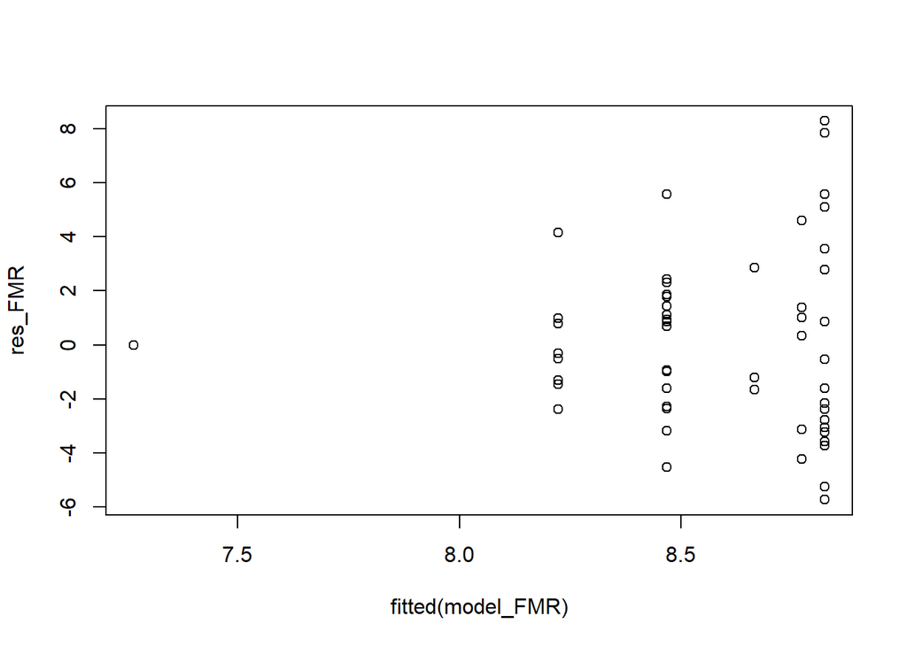

```r
#Further analyses on flight metabolic rate
#Examine residuals
model_FMR = aov(mlHrCO2_avg~Age*Sex, data = Exp_2_data_08_07_21)
res_FMR = resid(model_FMR)
plot(fitted(model_FMR), res_FMR) #skewed right - one data point way off, not sure why
```

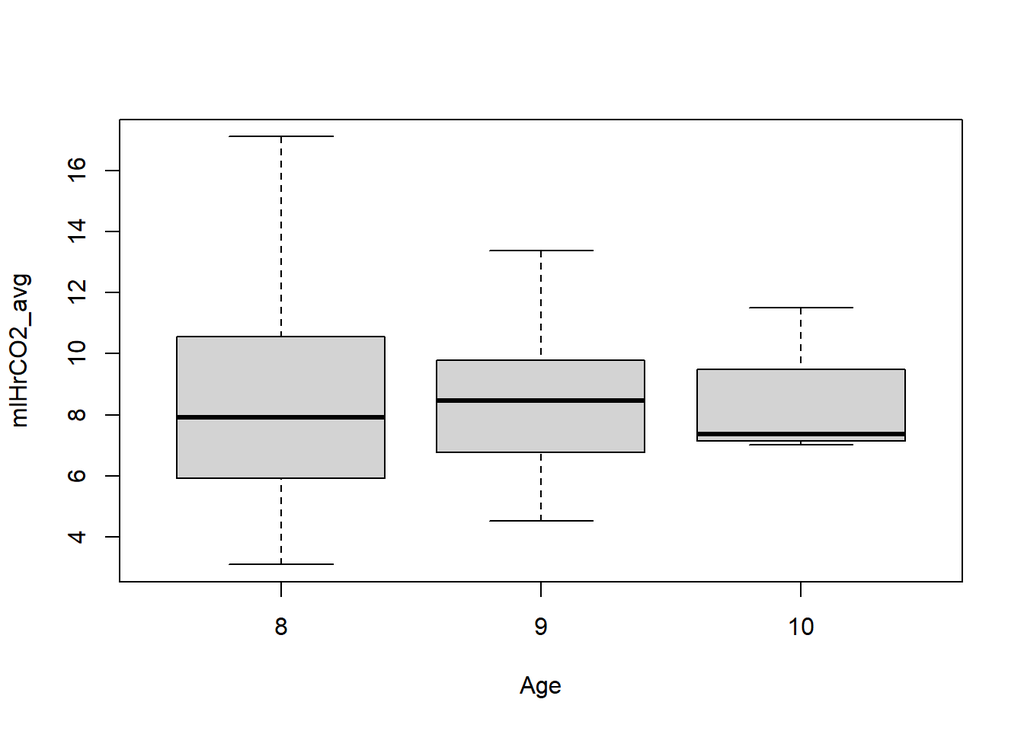

```r
#Visualize data spread of FMR vs. Age
plot(mlHrCO2_avg~Age, data = Exp_2_data_08_07_21)
```

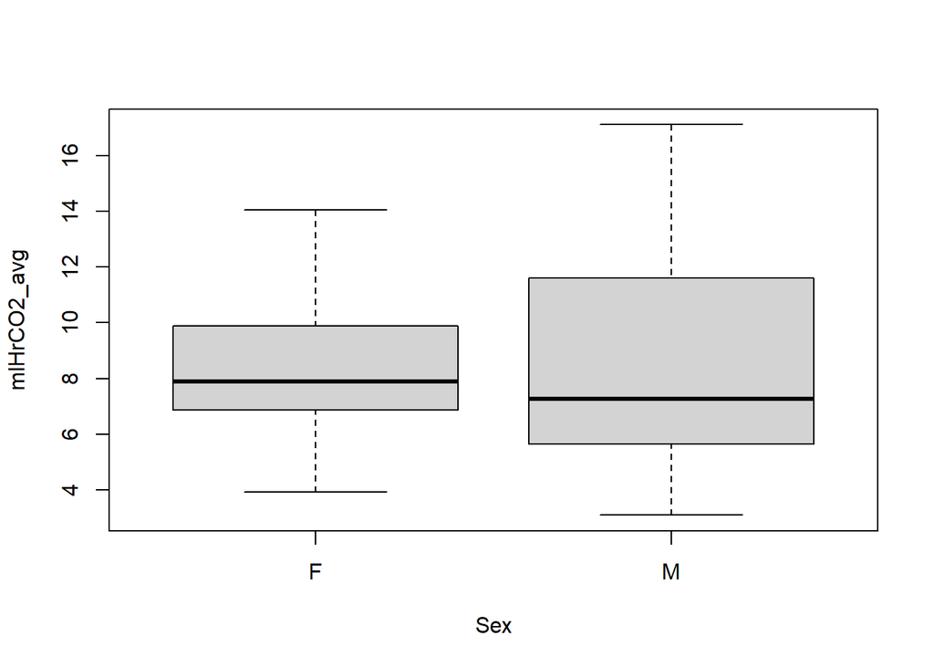

```r
#Visualize data spread of FMR vs. Sex
plot(mlHrCO2_avg~Sex, data = Exp_2_data_08_07_21)
abline(0,0)
```

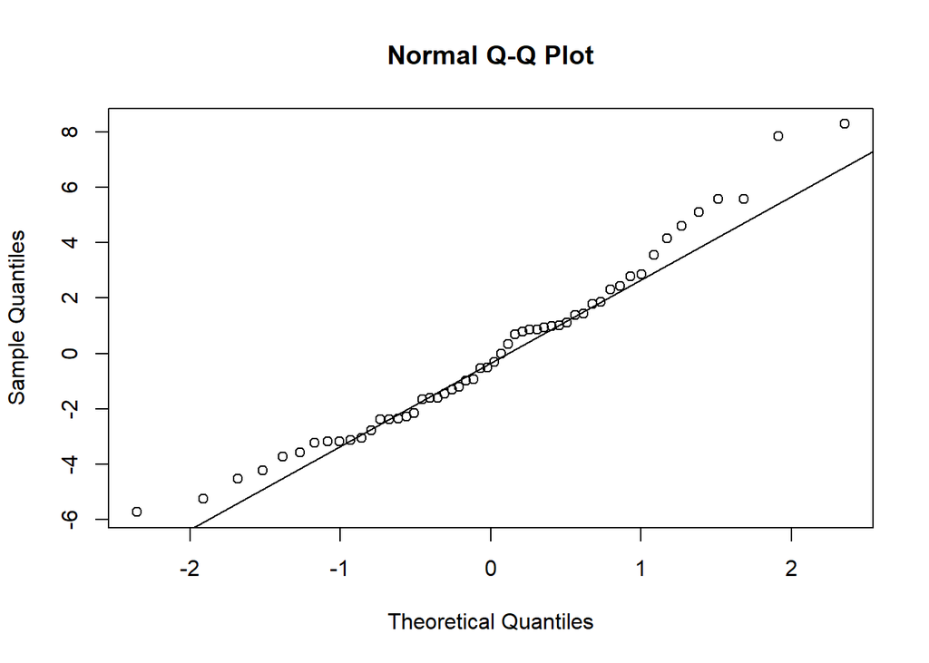

```r
qqnorm(res_FMR)
qqline(res_FMR)
```

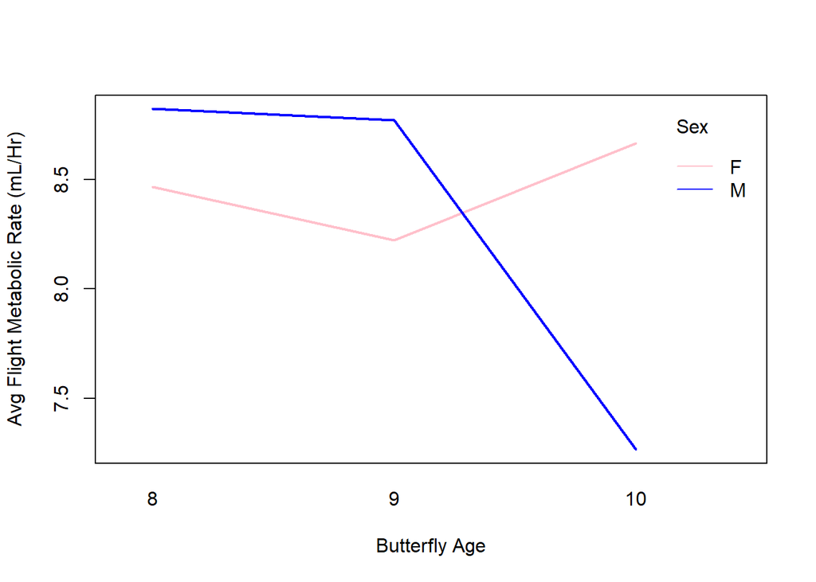

```r
remove(model_FMR)
remove(res_FMR)
#interaction plot (should see no interaction)
interaction.plot(x.factor = Exp_2_data_08_07_21$Age, #x-axis variable
                 trace.factor = Exp_2_data_08_07_21$Sex, #variable for lines
                 response = Exp_2_data_08_07_21$mlHrCO2_avg, #y-axis variable
                 fun = mean, #metric to plot
                 ylab = "Avg Flight Metabolic Rate (mL/Hr)",
                 xlab = "Butterfly Age",
                 col = c("pink", "blue"),
                 lty = 1, #line type
                 lwd = 2, #line width
                 trace.label = "Sex")
```

*Again seeing a graphical interaction (apparently) while statistical tests show no interaction. Probably due to uneven distribution of data points collected for each of the days.*

Since resting metabolic rate had some differences between normalized and non-normalized significance in Age, an interaction model between butterfly mass and age was run

```r
Anova(lm(rmr_mlHrCO2 ~ Age * pre_flight_weight, data = Exp_2_data_08_07_21), type = 3)
```

```
## Anova Table (Type III tests)
##
## Response: rmr_mlHrCO2
##                        Sum Sq Df F value    Pr(>F)
## (Intercept)           0.00031  1  0.0091 0.9245820
## Age                   0.41414  2  6.0027 0.0047123 **
## pre_flight_weight     0.26270  1  7.6153 0.0081692 **
## Age:pre_flight_weight 0.58068  2  8.4165 0.0007357 ***
## Residuals             1.65582 48
## ---
## Signif. codes:  0 '***' 0.001 '**' 0.01 '*' 0.05 '.' 0.1 ' ' 1
```

```r
#post-hoc analyses?

#check interaction in FMR too
Anova(lm(mlHrCO2_avg ~ Age * pre_flight_weight, data = Exp_2_data_08_07_21), type = 3)
```

```
## Anova Table (Type III tests)
##
## Response: mlHrCO2_avg
##                       Sum Sq Df F value  Pr(>F)
## (Intercept)            31.21  1  3.0268 0.08831 .
## Age                     3.04  2  0.1473 0.86344
## pre_flight_weight      29.55  1  2.8659 0.09696 .
## Age:pre_flight_weight   3.15  2  0.1528 0.85875
## Residuals             495.00 48
## ---
## Signif. codes:  0 '***' 0.001 '**' 0.01 '*' 0.05 '.' 0.1 ' ' 1
```

```r
Anova(lm(mlHrCO2_avg ~ Age + pre_flight_weight, data = Exp_2_data_08_07_21), type = 2)
```

```
## Anova Table (Type II tests)
##
## Response: mlHrCO2_avg
##                   Sum Sq Df F value  Pr(>F)
## Age                 0.03  2  0.0016 0.99844
## pre_flight_weight  44.59  1  4.4758 0.03938 *
## Residuals         498.15 50
## ---
## Signif. codes:  0 '***' 0.001 '**' 0.01 '*' 0.05 '.' 0.1 ' ' 1
```

- Correlations between weight and metabolic rates? *(Expect to see metabolic rate scale with mass)*

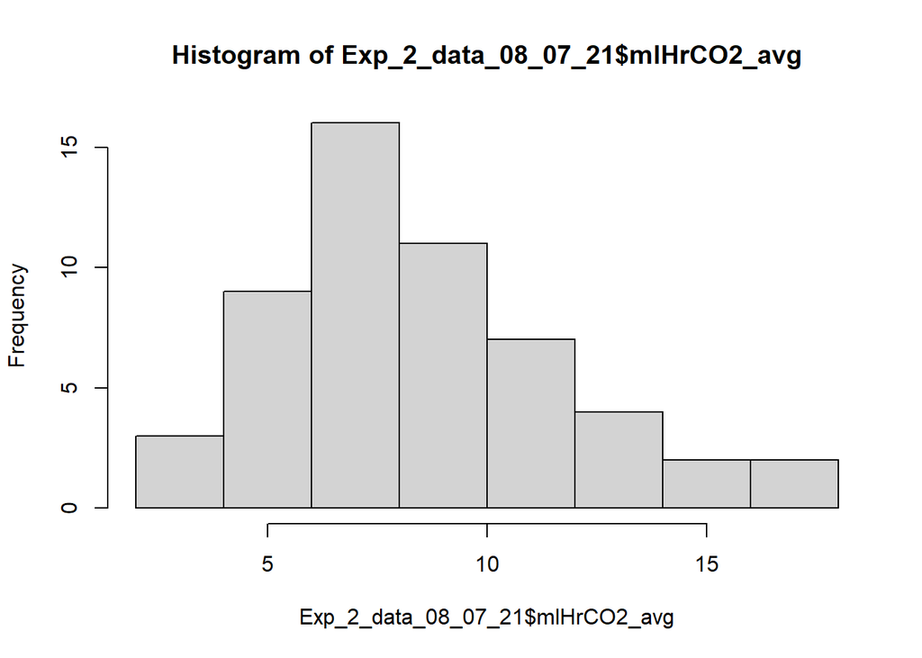

```r
#NORMALITY ASSUMPTIONS MET?
#Metabolic rate normality check
hist(Exp_2_data_08_07_21$mlHrCO2_avg)
```

```r
shapiro.test(Exp_2_data_08_07_21$mlHrCO2_avg)
```

```
##
##  Shapiro-Wilk normality test
##
## data:  Exp_2_data_08_07_21$mlHrCO2_avg
## W = 0.95723, p-value = 0.05179
```

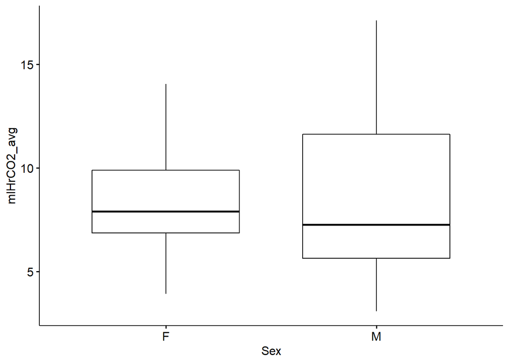

```r
ggboxplot(Exp_2_data_08_07_21, x = "Sex", y = "mlHrCO2_avg") #attempt to visualize outlier(s) - none plotted
```

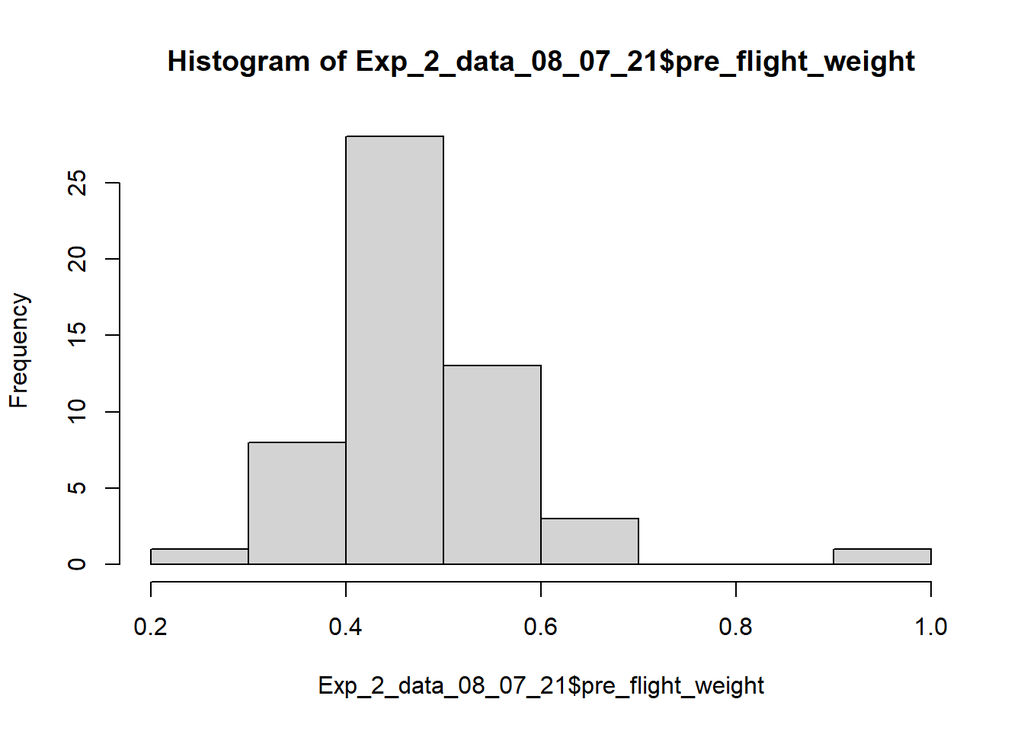

```r
#Mass normality check
hist(Exp_2_data_08_07_21$pre_flight_weight)
```

```r
#one butterfly way off
shapiro.test(Exp_2_data_08_07_21$pre_flight_weight) #low p-value = non-normal
```

```
##
##  Shapiro-Wilk normality test
##
## data:  Exp_2_data_08_07_21$pre_flight_weight
## W = 0.87959, p-value = 6.029e-05
```

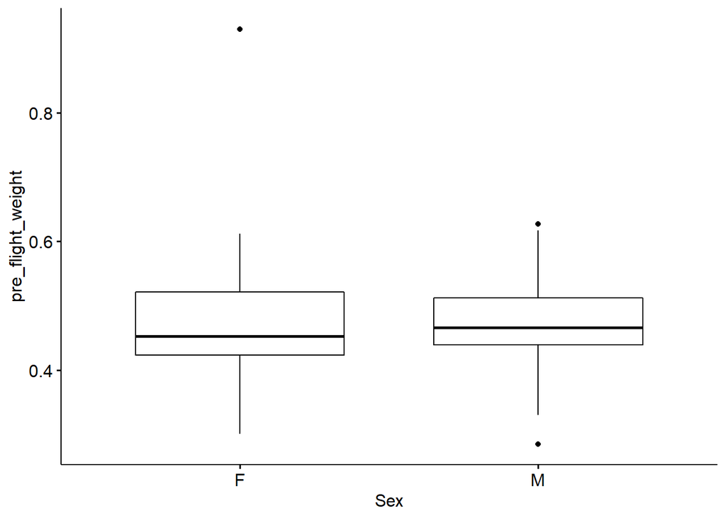

```r
ggboxplot(Exp_2_data_08_07_21, x = "Sex", y = "pre_flight_weight") #attempt to visualize outlier(s)
```

Because of the normality assumption being violated, mass data was re-examined and notes were consulted to determine if it would make sense to remove outliers. The data point at mass = 0.9 g was from a female (# FC5) noted to have had a swollen abdomen prior to flight test as well as bloated even further upon mortality. I wonder if this one was infected with something, then? The carcass was kept frozen.

*Further data was analyzed with FC5 data removed.*

## Analyses with large female data point removed

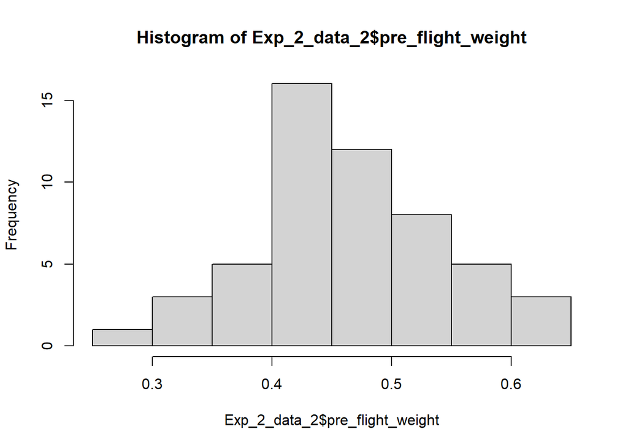

```r
Exp_2_data_2 <- Exp_2_data_08_07_21[-c(18),]

hist(Exp_2_data_2$pre_flight_weight)
```

```r
shapiro.test(Exp_2_data_2$pre_flight_weight) #p > 0.05 = normally distributed
```

```
##
##  Shapiro-Wilk normality test
##
## data:  Exp_2_data_2$pre_flight_weight
## W = 0.98845, p-value = 0.8862
```

```r
#test for homogeneity of variances and plot
bartlett.test(pre_flight_weight~Treatment, data = Exp_2_data_2)
```

```
##
##  Bartlett test of homogeneity of variances
##
## data:  pre_flight_weight by Treatment
## Bartlett's K-squared = 1.916, df = 1, p-value = 0.1663
```

```r
summary(aov(pre_flight_weight~Treatment, data = Exp_2_data_2))
```

```
##             Df Sum Sq  Mean Sq F value Pr(>F)
## Treatment    1 0.0060 0.005998   1.005  0.321
## Residuals   51 0.3042 0.005965
```

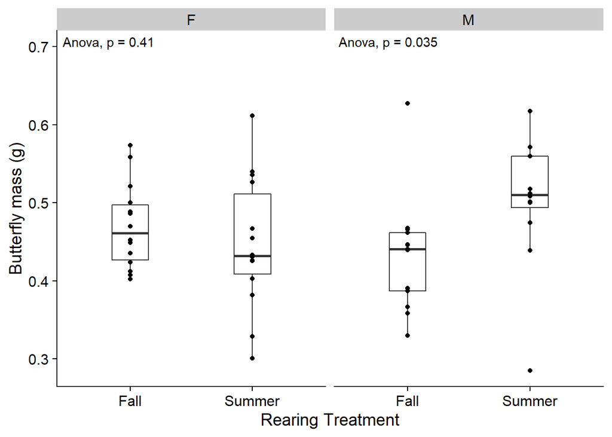

```r
ggplot(Exp_2_data_2, aes(x = Treatment, y = pre_flight_weight)) + labs(x = "Rearing Treatment", y = "Butterfly mass (g)") + geom_boxplot(width = 0.3) + geom_jitter(width = 0) + theme_cowplot() + stat_compare_means(method = "anova", label.x = 0.6, label.y = 0.7) + facet_wrap(~Sex)
```

```r
#test for interactions between sex and treatment
Anova(lm(pre_flight_weight ~ Sex * Treatment, data = Exp_2_data_2), type = 2)
```

```
## Anova Table (Type II tests)
##
## Response: pre_flight_weight
##                 Sum Sq Df F value  Pr(>F)
## Sex           0.000994  1  0.1775 0.67540
## Treatment     0.006093  1  1.0876 0.30212
## Sex:Treatment 0.028711  1  5.1249 0.02805 *
## Residuals     0.274507 49
## ---
## Signif. codes:  0 '***' 0.001 '**' 0.01 '*' 0.05 '.' 0.1 ' ' 1
```

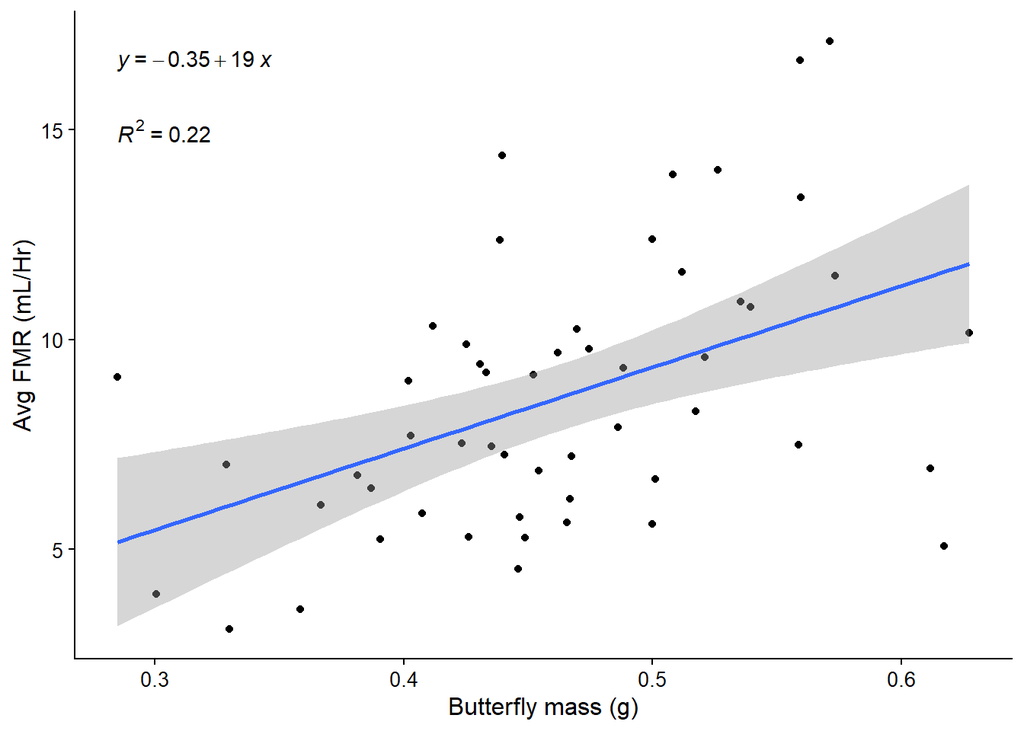

```r
#FMR correlation with mass - saved graph as "Mass_FMR_corr2.png"
ggplot(Exp_2_data_2, aes(x = pre_flight_weight, y = mlHrCO2_avg)) +
  labs(x = "Butterfly mass (g)", y = "Avg FMR (mL/Hr)") + geom_point() +
  geom_smooth(method = lm) + stat_regline_equation() +
  stat_cor(aes(label = ..rr.label..), label.y = 15) + theme_cowplot(12)
```

```r
cor.test(~mlHrCO2_avg+pre_flight_weight, data = Exp_2_data_2, conf.level = 0.95)
```

```
##
##  Pearson's product-moment correlation
##
## data:  mlHrCO2_avg and pre_flight_weight
## t = 3.7592, df = 51, p-value = 0.0004399
## alternative hypothesis: true correlation is not equal to 0
## 95 percent confidence interval:
##  0.2236701 0.6537831
## sample estimates:
##      cor
## 0.465803
```

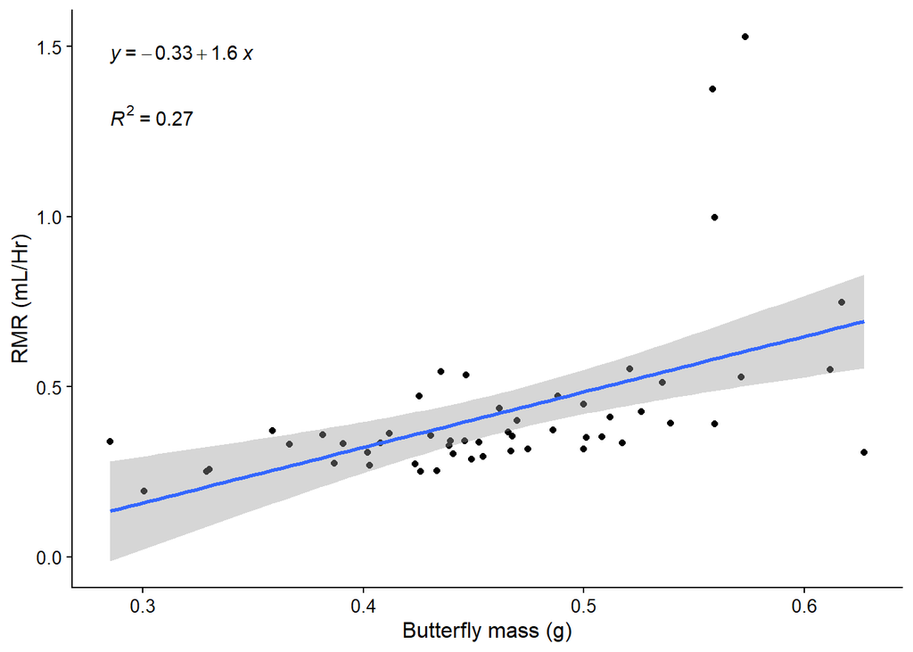

```r
#RMR correlation with mass - saved graph as "Mass_RMR_corr2.png"
ggplot(Exp_2_data_2, aes(x = pre_flight_weight, y = rmr_mlHrCO2)) +
  labs(x = "Butterfly mass (g)", y = "RMR (mL/Hr)") + geom_point() +
  geom_smooth(method = lm) + stat_regline_equation() +
  stat_cor(aes(label = ..rr.label..), label.y = 1.3) + theme_cowplot(12)
```

```r
cor.test(~rmr_mlHrCO2+pre_flight_weight, data = Exp_2_data_2, conf.level = 0.95)
```

```
##
##  Pearson's product-moment correlation
##
## data:  rmr_mlHrCO2 and pre_flight_weight
## t = 4.2979, df = 51, p-value = 7.768e-05
## alternative hypothesis: true correlation is not equal to 0
## 95 percent confidence interval:
##  0.2850813 0.6897956
## sample estimates:
##      cor
## 0.515642
```

```r
#Remove created objects
rm(Exp_2_data_08_07_21)
rm(Exp_2_data_2)
rm(Exp2_wings)
```